# RDA project

JBNU statistics

2021 12 14

## 목적 : 단동 비닐하우스 환기율 및 온습도에 대한 예측모형 구축 및 평가

## 사용모형 : Multiple Linear Regression Model v.s Artificial Neural Network Model (ANN)

## 1. Loading data (내외부CO2차 반응변수)

- 작물있음 데이터에서 외부CO2의 값이 결측치인 경우는 제외하였음.

```r
plantyes <- read.csv("C:/Users/HSY/Desktop/작물있음.csv",sep=",",header=T)
plantyes <- plantyes[is.na(plantyes$외부CO2)==FALSE,]
head(plantyes,10)
```

```
##    외부기온 내부기온 내외부기온차 외부상대습도 내부상대습도 내외부상대습도차
## 1      22.9     31.1          8.3         78.7         55.0             23.7
## 2      22.8     29.7          6.9         77.1         58.7             18.4
## 3      23.3     29.7          6.4         75.5         58.4             17.1
## 4      23.6     29.8          6.2         72.9         57.8             15.1
## 5      24.0     30.0          6.0         71.2         56.4             14.8
## 6      25.1     33.3          8.1         66.6         49.6             17.0
## 7      25.9     35.6          9.7         66.0         43.6             22.4
## 8      25.0     34.0          8.9         68.0         44.9             23.1
## 9      25.9     33.7          7.8         65.6         46.4             19.2
## 10     26.8     35.9          9.1         61.8         44.1             17.7
##    외부CO2 내부CO2 내외부CO2차 외부풍속 외부일사량 환기율 환기창면적 작물유무
## 1    469.5   462.0         7.5    1.398      372.7    5.4       0.15      yes
## 2    464.5   459.7         4.8    1.326      309.9    5.0       0.15      yes
## 3    457.5   451.3         6.2    0.835      291.9    4.0       0.15      yes
```

[output cut: 18 more lines]

```r
plantyes$작물유무 <- as.factor(plantyes$작물유무)
plantno <- read.csv("C:/Users/HSY/Desktop/작물없음.csv",sep=",",header=T)
head(plantno,10)
```

```
##    외부기온 내부기온 내외부기온차 외부상대습도 내부상대습도 내외부상대습도차
## 1      16.8     27.1         10.3         45.1         39.6              5.5
## 2      17.2     28.3         11.1         42.5         37.6              4.9
## 3      17.6     29.1         11.5         42.9         33.2              9.7
## 4      18.0     30.3         12.4         41.2         32.4              8.8
## 5      17.9     30.6         12.7         37.2         28.8              8.4
## 6      18.0     31.3         13.3         37.4         27.1             10.3
## 7      18.0     31.7         13.7         35.8         25.3             10.5
## 8      18.0     32.0         14.0         38.6         24.4             14.2
## 9      18.3     32.7         14.5         37.0         23.5             13.5
## 10     18.3     32.6         14.3         36.1         22.6             13.5
##    외부CO2 내부CO2 내외부CO2차 외부풍속 외부일사량 환기율 환기창면적 작물유무
## 1    543.5   608.0        64.5    1.576      409.4  0.704       0.04       no
## 2    543.0   580.0        37.0    1.707      442.7  0.756       0.04       no
## 3    522.5   585.5        63.0    1.342      476.5  0.634       0.04       no
```

[output cut: 18 more lines]

```r
plantno$작물유무 <- as.factor(plantno$작물유무)
plant <- rbind(plantno,plantyes)
```

## Multiple Linear Regression Model

## 2. 작물유무에 따라 데이터를 나누어서 분석 실시

### 2.1 작물이 없을 때

#### Multiple Linear Regression Model

- 먼저 변수들 간의 상관관계를 파악하기 위해 상관분석을 실시한다.

```r
ex1 <- plantno[,c(9,12,1,7,10,11,13,14,15)]
head(ex1)
```

```
##   내외부CO2차 환기율 외부기온 외부CO2 외부풍속 외부일사량 환기창면적 작물유무
## 1        64.5  0.704     16.8   543.5    1.576      409.4       0.04       no
## 2        37.0  0.756     17.2   543.0    1.707      442.7       0.04       no
## 3        63.0  0.634     17.6   522.5    1.342      476.5       0.04       no
## 4        50.5  0.798     18.0   543.0    1.802      505.7       0.04       no
## 5        70.0  1.084     17.9   520.5    2.583      536.0       0.04       no
## 6        56.0  1.493     18.0   529.5    3.660      564.9       0.04       no
##   작물유무수치
## 1            0
## 2            0
## 3            0
## 4            0
## 5            0
## 6            0
```

```r
ex2 <- ex1[,1:7]
```

```r
cor(ex2)
```

```
##             내외부CO2차     환기율      외부기온       외부CO2      외부풍속
## 내외부CO2차  1.00000000 -0.5065289  4.673543e-02 -9.192406e-02 -1.120144e-02
## 환기율      -0.50652891  1.0000000  1.668245e-01 -2.968640e-01  5.063954e-01
## 외부기온     0.04673543  0.1668245  1.000000e+00 -3.112018e-01  3.063871e-01
## 외부CO2     -0.09192406 -0.2968640 -3.112018e-01  1.000000e+00 -5.914228e-01
## 외부풍속    -0.01120144  0.5063954  3.063871e-01 -5.914228e-01  1.000000e+00
## 외부일사량   0.12103828  0.0608040  3.274643e-01 -4.942462e-02  4.772916e-02
## 환기창면적  -0.59990593  0.8309530 -9.044468e-20  1.450984e-19  3.715441e-20
##                외부일사량    환기창면적
## 내외부CO2차  1.210383e-01 -5.999059e-01
## 환기율       6.080400e-02  8.309530e-01
## 외부기온     3.274643e-01 -9.044468e-20
## 외부CO2     -4.942462e-02  1.450984e-19
## 외부풍속     4.772916e-02  3.715441e-20
## 외부일사량   1.000000e+00 -5.089237e-20
## 환기창면적  -5.089237e-20  1.000000e+00
```

- 산점도행렬과 상관계수그림을 그리면 다음과 같다.

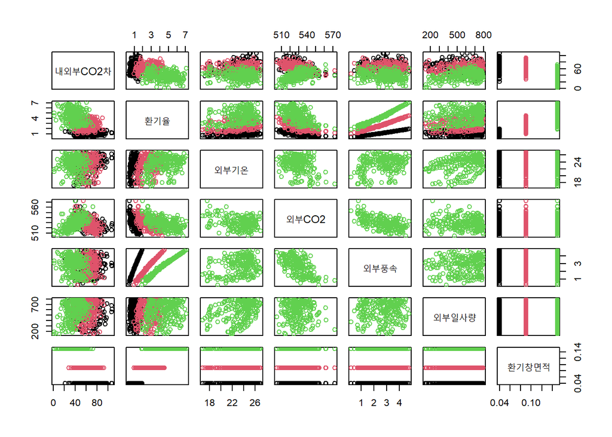

```r
pairs(ex2[1:nrow(plantno),],col=factor(ex2$환기창면적))
```

- 산점도를 통해 알 수 있는 사실은 환기율이 감소할수록 내외부CO2차가 증가한다는 점이다. 환기창면적과의 교호작용은 뚜렷하게 관측되는 것이 없으나, 외부풍속과의 교호작용의 존재 가능성이 추측된다.

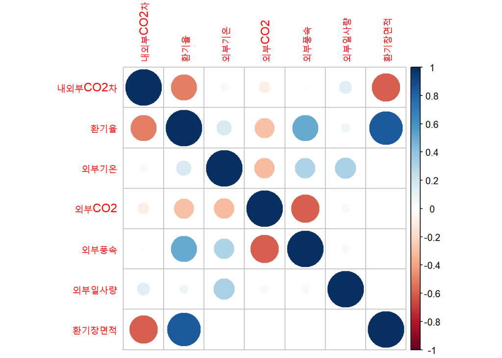

```r
library(corrplot)
corrplot(cor(ex2))
```

- 그리고 각 변수에 대한 기초통계량은 다음과 같이 계산된다.

```r
library(psych)
describe(ex1[,c(-8,-9)])
```

```
##             vars   n   mean     sd median trimmed    mad    min    max  range
## 내외부CO2차    1 735  54.28  17.94  54.50   54.47  19.27   1.00 107.50 106.50
## 환기율         2 735   2.81   1.64   2.64    2.68   1.86   0.32   7.09   6.78
## 외부기온       3 735  23.39   2.30  24.00   23.66   1.93  16.80  27.00  10.20
## 외부CO2        4 735 529.40  11.13 528.00  529.01  11.12 504.50 572.50  68.00
## 외부풍속       5 735   2.71   1.08   2.87    2.73   1.29   0.21   4.74   4.54
## 외부일사량     6 735 568.60 171.31 601.10  584.32 191.40 143.00 795.20 652.20
## 환기창면적     7 735   0.09   0.04   0.09    0.09   0.07   0.04   0.15   0.11
##              skew kurtosis   se
## 내외부CO2차 -0.07    -0.21 0.66
## 환기율       0.55    -0.67 0.06
## 외부기온    -0.98     0.30 0.08
## 외부CO2      0.47     0.44 0.41
## 외부풍속    -0.26    -0.99 0.04
## 외부일사량  -0.63    -0.61 6.32
## 환기창면적   0.11    -1.50 0.00
```

- 내외부CO2차를 반응변수로 하여 각 변수의 주효과와 환기창면적과의 교호작용을 고려한 다중선형회귀모형을 적합하면 다음과 같다.

```r
m_no <- lm(내외부CO2차~환기율+외부기온+외부CO2+외부풍속+외부일사량+환기창면적+환기창면적*환기율+환기창면적*외부기온+환기창면적*외부CO2+환기창면적*외부풍속+환기창면적*외부일사량,data=plantno)
summary(m_no)
```

```
##
## Call:
## lm(formula = 내외부CO2차 ~ 환기율 + 외부기온 + 외부CO2 + 외부풍속 +
##     외부일사량 + 환기창면적 + 환기창면적 * 환기율 + 환기창면적 *
##     외부기온 + 환기창면적 * 외부CO2 + 환기창면적 * 외부풍속 +
##     환기창면적 * 외부일사량, data = plantno)
##
## Residuals:
##     Min      1Q  Median      3Q     Max
## -52.052  -6.676   0.007   7.442  41.614
##
## Coefficients:
##                         Estimate Std. Error t value Pr(>|t|)
## (Intercept)            8.633e+02  6.298e+01  13.708  < 2e-16 ***
## 환기율                 1.609e+01  4.526e+00   3.555 0.000403 ***
## 외부기온               1.575e+00  4.827e-01   3.263 0.001152 **
## 외부CO2               -1.497e+00  1.108e-01 -13.511  < 2e-16 ***
## 외부풍속              -1.275e+01  1.275e+00  -9.999  < 2e-16 ***
## 외부일사량            -2.799e-02  6.094e-03  -4.594 5.13e-06 ***
## 환기창면적            -7.316e+03  6.081e+02 -12.031  < 2e-16 ***
## 환기율:환기창면적     -9.205e+01  1.184e+01  -7.772 2.66e-14 ***
## 외부기온:환기창면적   -1.771e+01  4.659e+00  -3.800 0.000157 ***
## 외부CO2:환기창면적     1.342e+01  1.071e+00  12.530  < 2e-16 ***
## 외부풍속:환기창면적    7.095e+01  4.545e+01   1.561 0.118951
## 외부일사량:환기창면적  4.168e-01  6.397e-02   6.515 1.36e-10 ***
## ---
## Signif. codes:  0 '***' 0.001 '**' 0.01 '*' 0.05 '.' 0.1 ' ' 1
##
## Residual standard error: 11.52 on 723 degrees of freedom
## Multiple R-squared:  0.5937, Adjusted R-squared:  0.5876
## F-statistic: 96.06 on 11 and 723 DF,  p-value: < 2.2e-16
```

- 모형적합 결과 외부풍속과 환기창면적 사이의 교호작용이 유의수준 0.05에서 유의미하지 않았다. 그러므로 이를 변수선택 시 제외해야 할 것으로 보인다.
- 그리고 교호작용들 중 외부CO2와 환기창면적, 그리고 환기율과 환기창면적 사이의 교호작용에 대한 t 통계량의 절대값이 첫번째와 두번째 순으로 가장 크므로 이를 가장 중요한 2가지 교호작용으로 결정한다.
- 조정된 결정계수의 값이 $R^2_{adj}=0.5876$이다.

#### Best subset selection

- 여러 측도들을 이용하여 모형에 포함될 변수를 적절히 선택해 보도록 하겠다.
- 분석 의뢰기관의 요청에 따라 환기율은 설명변수에서 제외하도록 한다.

```r
library(leaps)
ms0 <- regsubsets(내외부CO2차~외부기온+외부CO2+외부풍속+외부일사량+환기창면적+환기창면적*외부기온+환기창면적*외부CO2+환기창면적*외부풍속+환기창면적*외부일사량,data=plantno,nvmax=9)
ms0.summary <- summary(ms0)
ms0.summary
```

```
## Subset selection object
## Call: regsubsets.formula(내외부CO2차 ~ 외부기온 + 외부CO2 + 외부풍속 +
##     외부일사량 + 환기창면적 + 환기창면적 * 외부기온 + 환기창면적 *
##     외부CO2 + 환기창면적 * 외부풍속 + 환기창면적 * 외부일사량,
##     data = plantno, nvmax = 9)
## 9 Variables  (and intercept)
##                       Forced in Forced out
## 외부기온                  FALSE      FALSE
## 외부CO2                   FALSE      FALSE
## 외부풍속                  FALSE      FALSE
## 외부일사량                FALSE      FALSE
## 환기창면적                FALSE      FALSE
## 외부기온:환기창면적       FALSE      FALSE
## 외부CO2:환기창면적        FALSE      FALSE
## 외부풍속:환기창면적       FALSE      FALSE
## 외부일사량:환기창면적     FALSE      FALSE
## 1 subsets of each size up to 9
## Selection Algorithm: exhaustive
##          외부기온 외부CO2 외부풍속 외부일사량 환기창면적 외부기온:환기창면적
## 1  ( 1 ) " "      " "     " "      " "        "*"        " "
## 2  ( 1 ) " "      " "     " "      " "        "*"        " "
## 3  ( 1 ) " "      "*"     " "      " "        "*"        " "
## 4  ( 1 ) " "      "*"     " "      " "        "*"        " "
## 5  ( 1 ) " "      "*"     "*"      " "        "*"        " "
## 6  ( 1 ) " "      "*"     "*"      " "        "*"        " "
## 7  ( 1 ) " "      "*"     "*"      "*"        "*"        " "
## 8  ( 1 ) " "      "*"     "*"      "*"        "*"        "*"
## 9  ( 1 ) "*"      "*"     "*"      "*"        "*"        "*"
##          외부CO2:환기창면적 외부풍속:환기창면적 외부일사량:환기창면적
## 1  ( 1 ) " "                " "                 " "
## 2  ( 1 ) " "                " "                 "*"
## 3  ( 1 ) "*"                " "                 " "
## 4  ( 1 ) "*"                " "                 "*"
## 5  ( 1 ) "*"                " "                 "*"
## 6  ( 1 ) "*"                "*"                 "*"
## 7  ( 1 ) "*"                "*"                 "*"
## 8  ( 1 ) "*"                "*"                 "*"
## 9  ( 1 ) "*"                "*"                 "*"
```

```r
par(mfrow=c(2,2))
# RSS=SSE
plot(ms0.summary$rss,xlab="Number of Variables",ylab="RSS",type="l")
# Adj R^2
plot(ms0.summary$adjr2,xlab="Number of Variables",ylab="Adjusted RSq",type="l")
which.max(ms0.summary$adjr2)
```

```
## [1] 9
```

```r
points(which.max(ms0.summary$adjr2)
,ms0.summary$adjr2[which.max(ms0.summary$adjr2)
], col="red",cex=2,pch=20)
# Cp
plot(ms0.summary$cp,xlab="Number of Variables",ylab="Cp",type='l')
which.min(ms0.summary$cp)
```

```
## [1] 9
```

```r
points(which.min(ms0.summary$cp)
,ms0.summary$cp[which.min(ms0.summary$cp)
],col="red",cex=2,pch=20)
# BIC
plot(ms0.summary$bic,xlab="Number of Variables",ylab="BIC",type='l')
which.min(ms0.summary$bic)
```

```
## [1] 7
```

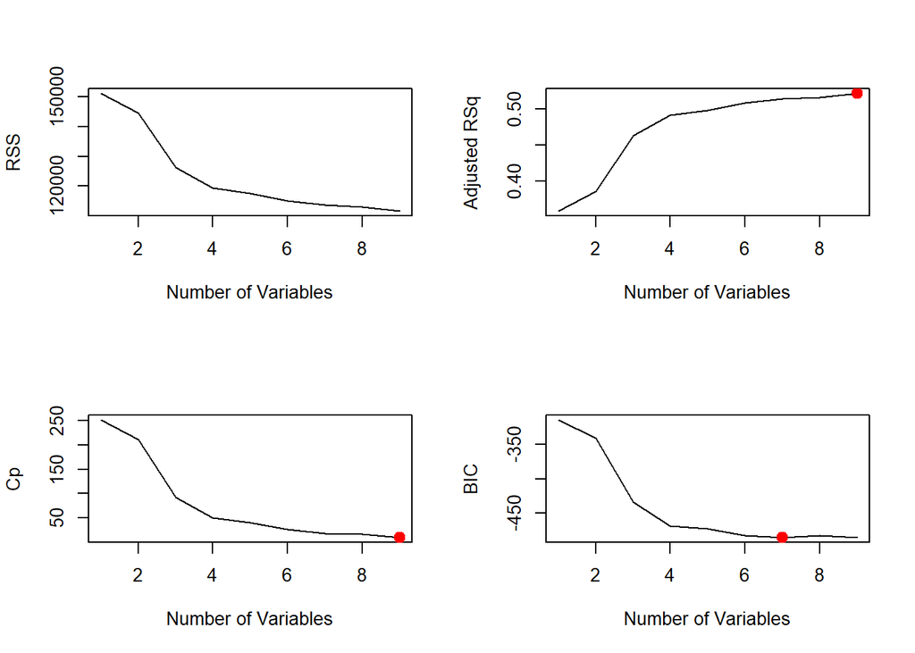

```r
points(which.min(ms0.summary$bic)
,ms0.summary$bic[which.min(ms0.summary$bic)
],col="red",cex=2,pch=20)
```

```r
par(mfrow=c(1,1))
```

```r
library(leaps)
ms0 <- regsubsets(내외부CO2차~외부CO2+외부풍속+외부일사량+환기창면적+환기창면적*외부CO2+환기창면적*외부풍속+환기창면적*외부일사량,data=plantno,nvmax=7)
ms0.summary <- summary(ms0)
ms0.summary
```

```
## Subset selection object
## Call: regsubsets.formula(내외부CO2차 ~ 외부CO2 + 외부풍속 + 외부일사량 +
##     환기창면적 + 환기창면적 * 외부CO2 + 환기창면적 * 외부풍속 +
##     환기창면적 * 외부일사량, data = plantno, nvmax = 7)
## 7 Variables  (and intercept)
##                       Forced in Forced out
## 외부CO2                   FALSE      FALSE
## 외부풍속                  FALSE      FALSE
## 외부일사량                FALSE      FALSE
## 환기창면적                FALSE      FALSE
## 외부CO2:환기창면적        FALSE      FALSE
## 외부풍속:환기창면적       FALSE      FALSE
## 외부일사량:환기창면적     FALSE      FALSE
## 1 subsets of each size up to 7
## Selection Algorithm: exhaustive
##          외부CO2 외부풍속 외부일사량 환기창면적 외부CO2:환기창면적
## 1  ( 1 ) " "     " "      " "        "*"        " "
## 2  ( 1 ) " "     " "      " "        "*"        " "
## 3  ( 1 ) "*"     " "      " "        "*"        "*"
## 4  ( 1 ) "*"     " "      " "        "*"        "*"
## 5  ( 1 ) "*"     "*"      " "        "*"        "*"
## 6  ( 1 ) "*"     "*"      " "        "*"        "*"
## 7  ( 1 ) "*"     "*"      "*"        "*"        "*"
##          외부풍속:환기창면적 외부일사량:환기창면적
## 1  ( 1 ) " "                 " "
## 2  ( 1 ) " "                 "*"
## 3  ( 1 ) " "                 " "
## 4  ( 1 ) " "                 "*"
## 5  ( 1 ) " "                 "*"
## 6  ( 1 ) "*"                 "*"
## 7  ( 1 ) "*"                 "*"
```

```r
par(mfrow=c(2,2))
# RSS=SSE
plot(ms0.summary$rss,xlab="Number of Variables",ylab="RSS",type="l")
# Adj R^2
plot(ms0.summary$adjr2,xlab="Number of Variables",ylab="Adjusted RSq",type="l")
which.max(ms0.summary$adjr2)
```

```
## [1] 7
```

```r
points(which.max(ms0.summary$adjr2)
,ms0.summary$adjr2[which.max(ms0.summary$adjr2)
], col="red",cex=2,pch=20)
# Cp
plot(ms0.summary$cp,xlab="Number of Variables",ylab="Cp",type='l')
which.min(ms0.summary$cp)
```

```
## [1] 7
```

```r
points(which.min(ms0.summary$cp)
,ms0.summary$cp[which.min(ms0.summary$cp)
],col="red",cex=2,pch=20)
# BIC
plot(ms0.summary$bic,xlab="Number of Variables",ylab="BIC",type='l')
which.min(ms0.summary$bic)
```

```
## [1] 7
```

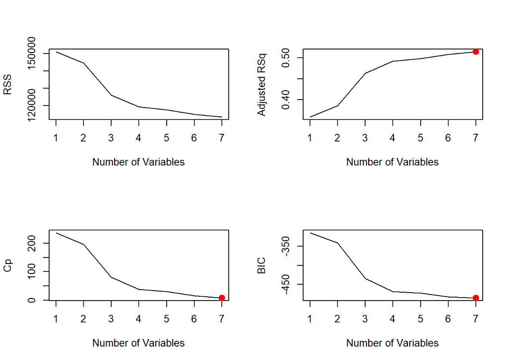

```r
points(which.min(ms0.summary$bic)
,ms0.summary$bic[which.min(ms0.summary$bic)
],col="red",cex=2,pch=20)
```

```r
par(mfrow=c(1,1))
```

- 분석결과 $R_{adj}^2$의 경우는 변수의 개수 7인 모형, $Cp$의 경우는 변수의 개수 7인 모형, 그리고 $BIC$의 경우는 변수의 개수 7인 모형을 최적으로 판단하고 있다. 이들 중 가장 단순한 모형인 변수의 개수 7인 모형을 최종적으로 선택하도록 한다.